# Chapter 11: Image Segmentation

A row image consists of a bunch of pixels, which is difficult to analyze and extract "useful" information about the image content. A more compact representation of an image is possible if we can find subgroups of pixels, which may correspond to some high level information, such as objects, object parts, boundaries, geometrical shapes, etc. These types of representations are possible by image segmentation methods, which partitions an image into "meaningful" groups of pixels.

Roughly speaking, image segmentation is the process of indexing image regions, such that the pixels in the same region are similar and the pixels in different regions are dissimilar to each other, with respect to some similarity or dissimilarity measure.

Algorithms developed for image segmentation involve a variety of methods, depending on the goal and application domain. These methods may

- partition an image into a set of **homogeneous regions**, which may correspond to an objects or object parts,
- extract **geometrical structures**, such as,
  - line segments,
  - circles, ellipses, polygons,
  - convex curve segments,
  - etc.
- extract object boundaries,
- etc.

  Based upon the major goals and the required outputs mentioned above, let us categorize and study the segmentation methods under each category, in the following sections.

## Types of Segmentation Algorithms

Segmentation algorithms can be categorized under two major headings, depending on the type of the information they used to output the desired results:

**1) Unsupervised segmentation:** These groups of algorithms are **context independent**. In other words, the segmentation algorithm blindly groups the pixels without considering the meaningful labels for the pixel groups. The output of these group of algorithms are called **partial segmentation**, which does not always correspond to meaningful regions. Figure 1 shows the result of a partial segmentation algorithm. In this course, we shall only consider methods under this category. \

[figure not shown]

Figure 1: An unsupervised segmentation algorithm detects the line-like and circular boundaries. It captures some pieces of object boundaries. However, it cannot extract the closed boundaries of objects, such as flowers, man and woman. Thus, it is not a complete segmentation.

**2) Supervised segmentation:** These groups of algorithms are **context dependent.** The high-level information about the image content is employed to enforce the output to be a complete segmentation. The output of these group of algorithms is called **complete segmentation**, where the image is partitioned into a set of objects and a background. Figure 2 shows the output of a complete segmentation, obtained by histogram thresholding method. The threshold value is determined by using a high level information about the gray values corresponding to the shadows, so that the shadow pixels are included in the background pixels. Most of the algorithms under this category require machine learning methods, where a labeled training set of segmented images is available. These methods are beyond the scope of this course.

[figure not shown]

Figure 2: The gray scale image consists of shadows, which may confuse the object and background. When we use the information corresponding to the gray values of shadows, we can determine a threshold value to extract the complete objects. Courtesy of Gonzales...

## Unsupervised Segmentation Methods

Dozens of unsupervised segmentation algorithms can be grouped under two headings:

**1) Region based segmentation:** This group of algorithms partitions the image into mutually exclusive and collectively exhaustive "homogenous" regions with respect to a predefined **similarity criterion** measured among the pixels. \

[figure not shown]

Figure 3: Region based segmentation. These algorithms group the pixels with similar colors under the same region. Note that the algorithm cannot extract the objects of sea and sky in a contiguous region, but it splits the objects into several regions.

**2) Edge based segmentation:** These algorithms, first, detect the edges by using an edge filter, which employs a pre-defined **dissimilarity metric**. Then, they group the edge pixels to extract object boundaries, line-like structures, geometrical shapes, such as circles, ellipses.

[figure not shown]

Figure 4: Edge based segmentation. This algorithm detects the edges on line segments. Note that the algorithm cannot extract the blocks, but it detects linear pieces of object boundaries. Thus, it is a partial segmentation algorithm.

In this chapter, we explore several region based segmentation algorithms, whereas we devote Chapter 12 to edge based segmentation algorithms.

### Region Based Segmentation

The formal definition of region based image segmentation is given below:

**Definition** (by T. Pavlidis) : **Region based image segmentation** partitions an image, $f(x,y)$, into a set of **collectively exhaustive and mutually exclusive regions**, $R= \bigcup_{i=1}^{N} R_i $, satisfying the following conditions:

1) Collectively exhaustiveness: Partition, $R$, covers the whole image: $$f(x,y)= \bigcup_{i=1}^{N} R_i$$

2) Mutually exclusiveness: Regions do not intersect with each other: $$R_i \cap R_j = \varnothing, \quad \forall i \neq j,$$

where $\varnothing$ indicates the null set.

3) A predefined **homogeneity predicate**, **$P$**, is TRUE within the pixels in each region and FALSE between the adjacent regions. Mathematically, for the pixels, $(x,y)\in R_i$, $$ P(R_i) = \text{TRUE}, \forall R_i,$$

and for the pixels in adjacent regions, $R_i$ and $R_j$ , $\quad \forall i\neq j$,

$$P(R_i \cup R_j) = \text{FALSE}.$$

**Definition:** The output, $f(x,y)= R= \bigcup_{i=1}^{N} R_i$, of a region based segmentation algorithm, which indexes all the pixels by a region index, $R_i$, is called the **segmentation map**.

Estimating the segmentation map of an image requires the definition of a homogeneity predicate, $P(.)$, which defines the conformity of all points in a region to the region model.

**Motivating Question**: How do we define a homogeneity predicate, which partitions the image into a set of regions, $R= \cup R_i $, in a "meaningful" way?

The answer to the above question is still a research problem and it heavily depends on the application domain.

The available segmentation algorithms employ a large variety of homogeneity predicates, one of which is given in the following example:

> **Example: Color similarity predicate**: Consider a color image, represented by

$$f(x,y): (x,y)\in I^2 \rightarrow c_i\in I^3 ,$$

where each pixel at the coordinate $(x,y)$ is represented by an RGB color vector, $${c_i} = {[r_i \quad g_i \quad b_i]}.$$

> Define a similarity predicate, which segments an image into a set of mutually exclusive and collectively exhaustive regions, each of which consists of the constant color.

**Answer:** We define the similarity between two colors by the Euclidean distance between the color vectors, $$D_E(c_i, c_j) = (r_i - r_j)^2 + (g_i - g_j)^2 + (b_i - b_j)^2.$$

The required homogeneity predicate is to be TRUE, when all the pixels in a region $R_k\in R$, have exactly the same color. Mathematically, $$P(R_k) =\text{TRUE}, \quad \text{for} \quad D_E(c_i,c_j) =0, \quad\forall c_i, \forall c_j\in R_k$$

and the colors of the pixels in two **adjacent** regions, $R_k\in R$ and $R_l\in R$ are to be strictly different. Mathematically,

$$P(R_k\cup R_l) =\text{FALSE} \quad \text{for} \quad D_E(c_i,c_j)\neq 0, \quad\forall c_i\in R_l, \forall c_j\in R_k , k\neq l.$$

The above example does not always generate a partition, which is consistent with the human visual system. As an example, consider the painting of Figure 5. Noticeably, in this painting, the leaves of the lilies are the variants of light green, the flowers are bluish, and the ground are brownish colors. If we would like to partition the painting into lily flowers, leaves and ground, we need to relax the above homogeneity predicate as follows;

$$P(R_k)=\text{TRUE}\quad\text{for}\quad D_E(c_i, c_j) \leq T, \quad\forall c_i, \forall c_j\in R_k$$

and $P(R_k\cup R_l)=\text{FALSE},\quad \text{for}\quad D_E(c_i,c_j)\gt T, \quad\forall c_i\in R_l, \forall c_j\in R_k, k\neq l,$

where $T$ is a predefined threshold, which is large enough to group the lily flowers, leaves and, the ground under the same segmentation regions and small enough to discriminate these objects. The above homogeneity predicate is TRUE if all the pixel colors in the region are similar to each other with respect to the Euclidean distance.

[figure not shown]

Figure 5: Lilies of Vincent van Gogh.

It is possible to define homogeneity predicates by using similarity measures between

- The color histograms of regions,
- The most dominant colors of regions
- Texture similarity of regions
- Region color means and variances,
- etc.

  In most practical problems, it is not easy to find a homogeneity predicate, which partitions the image into meaningful regions. As an example, consider the drawing of Maitrus.C. Escher, where the sky and water are almost impossible to partition, as well as the birds and the fish.

[figure not shown]

Figure 6: Sky and water of Maurits C.Escher.

**Programming exercises:**

1. Run the following code to perform edge based segmentation.
2. Change sigma, low threshold and high threshold parameters of the Canny edge detector and observe how the output changes.

```
(-0.5, 301.5, 402.5, -0.5)
```

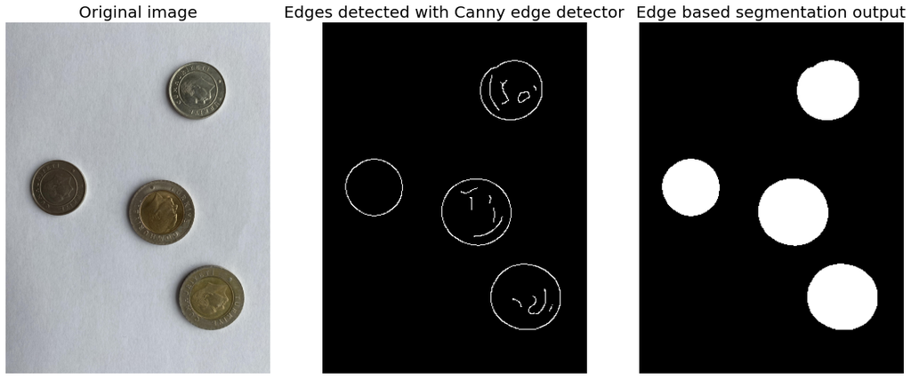

```python
## Edge Based Segmentation
#Segment the coins to obtain a binary image where pixels representing the coins are set to 1.

from skimage import io, feature, color
from skimage.util import img_as_ubyte
import matplotlib.pyplot as plt
import numpy as np
from scipy.ndimage.morphology import binary_fill_holes
from skimage.morphology import square, disk
from skimage.filters.rank import median
from skimage.transform import rescale

# Load image and convert it to grayscale
!wget -cq https://raw.githubusercontent.com/hazalmogultay/466Images/master/W12/coins.jpeg
im = io.imread('coins.jpeg')
im_g = color.rgb2gray(im)
im_g = rescale(im_g, 0.1, anti_aliasing=False)

# Apply median filter
im_g = median(im_g, disk(3))

# Detect edges with Canny edge detector
edge_canny = feature.canny(im_g, sigma=3,low_threshold=15, high_threshold=20)

# Fill in the circles
img_fill = binary_fill_holes(edge_canny).astype(int)


plt.figure(figsize=(20,20))
plt.subplot(131)
plt.imshow(im, cmap="gray")
plt.title("Original image", fontsize=20)
plt.axis("off")

plt.subplot(132)
plt.imshow(edge_canny, cmap="gray")
plt.title("Edges detected with Canny edge detector", fontsize=20)
plt.axis("off")


plt.subplot(133)
plt.imshow(img_fill, cmap="gray")
plt.title("Edge based segmentation output", fontsize=20)
plt.axis("off")
```

### Region Based Image Segmentation

Dozens of region based image segmentation algorithms can be grouped under three headings:

1) Region Growing Algorithms

2) Split and Merge Algorithms

3) Clustering Algorithms.

#### Region Growing Algorithms

**Region growing** algorithms start with a set of seed pixels, which is expected to be the pixels from potential regions, and try to **grow** the seed pixels by adding the neighboring pixels to the seed, as long as a pre-defined homogeneity predicate is TRUE. Among many homogeneity predicates, a popular one is the T-statistics test.

**Definition: T- Statistics Test Predicate:** Let $R_k$ be a region with $N_k$-pixels, at iteration $k$ and $f(x,y)$ is the brightness values of the pixels in $R_k$. Assume that the pixel brightness values in a region, $R_k$, is a random variable with the integer value, $c_i= f(x,y)$. Assume that the normalized color histogram can be approximated by the Gaussian probability density function, given below:

$$p_k(c_i) =\frac{1}{\sqrt{2\pi\sigma_k}} e^{-\frac{1}{2\sigma^2_k}(c_i-\mu_k)^2}.$$

Then, the color mean $\mu_k$ and variance $\sigma_k^2$ of this region can be approximated by $$\mu_k \approx \frac{1}{N_k} \sum_{(x,y) \in R_k}f(x,y),$$ and $$\sigma_k^2 \approx \frac{1}{N_k}\sum_{(x,y) \in R_k} (f(x,y) - \mu_k)^2.$$

Suppose that we augment the region $R_k$ by adding a single pixel with color value, $c_i$, which is adjacent to $R_k$. As long as the added pixels are close to the mean value, $\mu_k$, we can index them with the index of $R_k$, as we keep growing the region. Otherwise, we stop growing the region $R_k$ and start a new region with an unindexed seed pixel. Based upon this idea, a popular value in statistics, called, T-value is adopted to define a similarity predicate of a region, $R_k$, for each added pixel, with color value $c_i$ as follows;

$$T_i(R_k) =\frac{N_k(N_k-1)}{N_k+1}.[\frac{(c_i-\mu_k)^2}{\sigma_k^2}]^{1/2}.$$

The multiplicative factor, $\frac{N_k(N_k-1)}{N_k+1},$ is used for normalizing the $T_i(R_k)$ values. The second term is the exponent of the Gaussian density function. It measures the distance of the color value, $c_i$, of a pixel from the mean value of the Gaussian distribution, normalized with its variance.

Then, we can define an intuitively meaningful predicate, called **T-statistics test predicate** as follows;

$$P(R_k) = \begin{cases} \text{TRUE} &\text{for} \quad T_i(R_k)\lt\tau \\ \text{FALSE} & \text {otherwise},\end{cases}$$

where $\tau$ is a predefined confidence value. Small values of $\tau$ results in small regions. As we enlarge $\tau$, the homogeneous regions get bigger and bigger.

There are two basic approaches for growing the regions around the seed, namely the sequential approach and the parallel approach, as described below.

**1. Sequential Approach:** The seed pixels are selected in a sequential manner. The region around a single seed is augmented by the neighboring pixels until the homogeneity predicate becomes FALSE. Then, another seed pixel is selected among the unindexed pixels for growing. The process continues until all the pixels are indexed.

**Algorithm: Sequential Region Grow**

Input: Image $f(x,y)$ and an arbitrarily selected seed pixel $R_0=p$.

Output: Segmentation map of regions with similar colors.

For each $k$, select a seed pixel with brightness value, $r_k$ and repeat,

1. Grow the region $R_k$ around the seed pixel, $r_i$ by adding the neighboring pixels to the seed and update $\mu_k$ and $\sigma_k^2$, as long as the homogeneity predicate is $P(R_k) =\text{TRUE}$ and index all the pixels with $R_k.$
2. When the predicate, $P(R_k) =\text{FALSE}$, set $k=k+1$ and select an unindexed pixel as a seed to start a new region, $R_{k+1}$ and go to step 1.
3. Stop, when all the pixels are indexed.

**2. Parallel Approach:** Several seed pixels are selected randomly. The algorithm grows all the regions around the seed, in parallel, as long as the homogeneity predicate is TRUE. When the predicate becomes FALSE, new seeds are added from the unlabeled regions of the image.

The parallel region growing algorithm is very similar to the sequential one, except that we start with multiple seed pixels and process them in parallel until we index all the pixels.

**Note:** The segmentation map obtained at the output of a region growing algorithms depends on the selected seed pixels. One way to solve this problem is to run the segmentation algorithm with different set of initial seeds, and to design a post processing step to generate a consensus among the segmentation maps obtained by different set of seed pixels.

[figure not shown]

Figure 7: Sequential region grow algorithm example. (Original image (up). Segmentation map (down). Not so great and the output heavily dependent on the selection of the initial seeds.

### Split and Merge

Rather than starting from a seed pixel and growing a region around the seed, we can start with the whole image and keep splitting it until the T- statistics test predicate becomes TRUE for all the segments. This method is called the **splitting method**.

**Example:** Suggest a simple segmentation algorithm for a given homogeneity predicate $P(.)$, using a splitting method.

**Answer:** Extracting the quad tree can be considered as a segmentation algorithm, which employs the splitting method.

**Algorithm: Quad Tree Segmentation Method**

Input: Whole image, $R_{00} =f(x,y).$

Output: The segmented regions obtained at the leaves of the quad tree.  
Initialize with $R_{00}.$

At each iteration $k$,

1. Split region $R_{jk}$ into four quadrants, if $P(R_{jk}) = \text{FALSE}.$
2. Stop, when $\forall R_{jk}$ , the homogeneity predicate is $P(R_{jk}) = \text{TRUE}.$

We can further improve the splitting algorithm by checking the T-statistics test predicate between the adjacent regions, at each iteration. When the homogeneity predicate becomes TRUE in two adjacent regions, we merge them. This improved method is called the split and merge method.

**Algorithm: Split and Merge Segmentation Method**

Input: Whole image, $R_0 = f(x,y).$

Output: Segmentation map

For each $k$ repeat,

1. Check for the T-statistics test predicate.

   If $P(R_k) = \text{TRUE}$ , stop.

   Else, Split $R_k$ into four quadrants, $R_{k1},R_{k2},R_{k3},R_{k4}. $
2. Check for the T-statistics test predicate for all the adjacent regions.

   If $P(R_{ki}\bigcup R_{kj}) =\text{TRUE}$, merge them.

   Else, keep $R_{ki}$ and $R_{kj}$ disjoint.
3. Repeat steps 1 and 2, iteratively until no more splitting or merging occurs.

The split and merge idea is good, but the results are blocky (See Figure 8).

[figure not shown]

Figure 8: The output of the split and merge algorithm (down) of the bird image (up).

There are many different versions of the split and merge algorithm, developed for different application domains. As an example, we can start with an arbitrary partition of an image and improve the initial partition by split and merge method using the T-statistical test predicate. Instead of splitting the image into four quadrants for $P(R_k) = \text{FALSE}$ , we can split the region arbitrarily into two regions.

### Clustering Techniques for Segmentation

Clustering, sometimes called unsupervised learning, is a general approach to group the samples of a dataset into several subsets, each of which shares some common properties. The samples in each subset, called cluster, are "similar" to each other, whereas the data in different subsets are "dissimilar", with respect to some similarity or dissimilarity criteria. Clustering is a very crucial task in data analysis, information retrieval, bioinformatics, data compression, computer graphics, computer vision, and machine learning.

In Image Analysis, clustering methods are used for the segmentation of an image into regions with "similar" pixel groups, which correspond to objects or object parts. The similarity metrics used in image segmentation are mostly based on the color similarity of pixels, extracted from the color histogram. However, in general, it is possible to define similarities of pixels based on edge histograms or the texture of image regions. In the following sections, we only consider color similarities among the pixels, keeping in mind that there are many other properties of images, such as granularity, regularity, etc., which can be used to measure the similarity of image regions.

A large variety of clustering techniques used for image segmentation can be grouped under two headings:

1. Statistical Clustering
2. Deterministic Clustering.

Let us study these techniques in the following subsections.

#### Statistical Techniques for Clustering

Statistical clustering techniques assume that the data is drawn from a [multimodal probability density function](https://en.wikipedia.org/wiki/Multimodal_distribution), $p(c_i)$, which consists of a mixture of several conditional probability density functions, $p(c_i/w_i)$, where $w_i, i=1,..., K$ is the index of cluster $i$. In case of image segmentation, the pixel color values, $c_i =f(x,y)$, can be assumed to be the random variable and the multimodal density function, $p(c_i)$ can be approximated by the normalized color histogram,

$$p(c_i) \approx h(c_i) = \frac{N_i}{N},$$

where $N_i$ is the number of pixels with color $c_i$ and $N$ is the number of pixels in an image.

Mathematically speaking, given a dataset of $N$ samples, the multimodal probability density function with $K$ modes can be represented by a mixture of $K$ conditional probability density functions as follows;

$$p(c_i) = \sum_{k=1}^{K}p(w_k)p(c_i/w_k),$$

where $p(w_i)$ is the priori probability for each cluster with $N_i$ samples, and it is approximated by

$$P(w_k)\approx N_k/N.$$

Note that, $N= \sum_{k=1}^N N_k.$ Thus,
$$0\le P(w_k)\le 1$$ and

$$\sum_{k=1}^K P(w_i) =1.$$

A popular assumption for the conditional probability density function, $p(c_i/w_k)$ of each component in the mixture is a Gaussian density function. Depending on the type of the random variable, $c_i$, the conditional probability density functions can be **univariate** or **multivariate** Gaussian functions as defined below:

**Definition: Univariate Gaussian Density function:** When the image is gray scale, the random variable, $c_i$ has **scaler values.** Then, the density function is called the **univariate Gaussian density function** and it is defined by the following analytical form;

$$p(c_i/w_k) = \frac{1}{\sqrt{2\pi}\sigma_k}exp[-\frac{1}{2\pi\sigma^2}(c_i-\mu_k)]^2,$$

where the scalar mean $\mu_k$ and variance $\sigma_k$, of each clustered, can be estimated by

$$\mu_k \approx \frac{1}{N_k} \sum_{c_i \in w_k}c_i,$$

and

$$\sigma_k^2 \approx \frac{1}{N_k}\sum_{c_i \in w_k} (c_i - \mu_k)^2.$$

The univariate density functions with the scaler valued random variable, $c_i$ represents the gray scale images.

[figure not shown]

Figure 9: Histogram of a gray scale image (upper left) and three Gaussian density functions, fitted to the histogram by K-Means clustering method (lower left). Similarly, we can fit 2-dimensional (upper right) or 3-dimensional (lower right) Gaussian distribution to color histograms.

For color or multi-spectral images, we need to generalize the univariate Gaussian density function to multivariate Gaussian function, as follows:

**Definition: Multivariate Gaussian Density Function:** When the random variable, $\bf{c_i}$ is a d-dimensional vector,

$$\bf{c_i} = [c_{i1}....c_{id}],$$

as in the multi-spectral and color images, **multivariate Gaussian density function** has the following analytical form;

$$p(\bf{c}_i/w_k) = \frac{1}{(2\pi)^{d/2}{|\Sigma_k|}}exp[-\frac{1}{2}[c_i-\mu_k)]^T\Sigma^{-1}[(c_i-\mu_k)].$$

where the mean, $\bf {\mu}_k$ can be approximated by a d-dimensional vector, $$\bf{\mu}_k \approx 1/N_k \sum_{\forall c_i\in w_k} c_i$$

and $dxd$ covariance matrix, $\Sigma_k$ can be approximated by

$$\Sigma_k \approx 1/N_k \sum_{\forall c_i\in w_k} [\bf{c}_i-\bf{\mu}_k][c_i-\mu_k]^T,$$

where $T$ indicates the vector transpose operation.

For color images, represented in one of the three-dimensional color space, the dimension of $c_i$ is $d=3$ and for a multi-spectral image $d$ takes the value of number of bandwidths and can be as large as couple of hundred.

[figure not shown]

Figure 10:The histogram of a color image is represented in three dimensional color space, where each point in this space corresponds to the color coordinate, $\bf{c_i}$ of a pixel. Multi-spectral Gaussian mixture is used to approximate this histogram. Note that in this representation, the spatial coordinates $(x,y)$ of pixels, disappear.

**Note:** Statistical clustering methods do not employ the pixel neighborhood information. Thus, two nonadjacent regions may fall into the same cluster, as long as the color values at multiple nonadjacent regions are similar with respect to some similarity measures. As a result, number of homogeneous regions are much larger than the number of clusters.

**Motivating Question:** Given the color histogram of an image, how can we find a segmentation map, using the above formulation?

If we knew the cluster means, we could group the pixel color values by assigning a pixel to the "nearest" cluster mean to find the segmentation map. Similarly, if we knew the segmentation map, we could easily estimate the cluster means and variances using the colors with the same index. Unfortunately, this is a chicken and egg problem. All we have is the color vectors of image pixels and the corresponding normalized histogram, $h(c_i)$, which approximates the mixture density,

$$p(c_i)\approx h(c_i).$$

**Motivating Question:** Can we estimate the cluster means and variances from the color histogram of an image?

There is a large variety of techniques in Data Science to estimate the mean values and variances of a mixture density from a given dataset. A pragmatic approach is to estimate the cluster means by minimizing the least square error with respect to the cluster means,

$$D = argmin_{\mu_k}\sum_{k=1}^{K} \sum_{x_i \in w_k} ||\bf{c_i} - \bf{\mu_k}||^2,$$

where ||.|| indicates any norm which measures the distance between two vectors.

Then, we estimate the variances, $\Sigma_k$ for all $k=1,...K$.

**Motivating Question:** Can we develop an iterative algorithm to cluster the colors, $\bf{c_i}$, of a dataset of pixels and estimate $\bf{\mu_k}$ and covariance matrix, $\Sigma_k$ of each mixture component, at the same time?

A trivial and very expensive answer to this question is to try all possible segmentation maps and out of all possible partitions into $K$ clusters, we choose the one that minimizes $D$.

Fortunately, there are some practical methods to find a segmentation map, which minimizes the cost function , $D$. In this course we study three well known methods for statistical clustering, which fit a mixture density to the color histogram of an image and generate a segmentation map:

1. K-Means Clustering
2. Mean Shift Clustering
3. Histogram Thresholding

### K-Means Clustering Method

Loosely speaking, K-Means clustering method iteratively fits a multivariate Gaussian mixture density function to the color histogram of an image and generates a segmentation map.

The idea behind K-Means clustering is simple. We start with an arbitrary set of cluster means, $\mu_1(1),....\mu_K(1)$ and obtain an initial segmentation map by asigning each pixel to the "nearest" mean value, using the Eucledean distance. At each iteration, $j$, we find the minimum Eucledean distance between the pixel colors and the mean values to generate a new segmentation map from,

$$D_E = argmin_{\mu_k(j)}\sum_{k=1}^{K} \sum_{x_i \in w_k} [\bf{c_i} - \bf{\mu_k(j)}]^T [\bf{c_i} - \bf{\mu_k(j)}].$$

The above definition of Euclidean distance implies that the trajectory of the equidistant samples from the mean vector is a hypersphere.

Then, we increment $j=j+1$ and estimate the new cluster means and covariances by using the segmentation map, $$\bf{\mu_k(j+1)} = 1/N_k \sum_{\forall c_i\in w_k} c_i,$$

where $N_k$ is the number of samples in cluster $k.$

The iterations repeat until there are no changes in the estimated cluster means. At the final iteration, $J$, we set

$$\bf{\mu_k} =\bf{\mu_k(J)}, \quad \forall k$$

and we can compute the covariance matrices, for all mixture components,

$$\Sigma_k = 1/N_k \sum_{\forall c_i\in w_k} [\bf{c_i} - \bf{\mu_k}] [\bf{c_i} - \bf{\mu_k}]^T.$$

[figure not shown]

Figure 11: Sample K-Means segmentation maps.

> **Algorithm: K-Means Clustering**

> **Input:** Image pixel colors, $\bf{c_i} =f(x,y)$, number of clusters, $K.$

> **Output:** Segmentation map and mean, $(\bf{\mu_1} ,\ldots, \mu_K)$ and covariance matrices, $(\Sigma_1,\ldots,\Sigma_K)$ of the Gaussian mixture density.
> 1. Set iteration count to $j=1$
> 2. Choose randomly a set of $K$ color means $\bf{\mu_1(1)} ,\ldots, \mu_K(1)$.
> 3. For each color vector $c_i$, compute $D_e(c_i, \mu_k(j)), k=1,…K$ and assign $c_i$ to the cluster $w_k$ with nearest mean to create a segmentation map.
> 4. Increment $j$ by 1, update the means to get $\bf{\mu_1}(j),\ldots,\mu_K(j).$
> 5. Repeat steps 3 and 4 until $\bf{\mu_k(j)} \approx \mu_{k}(j+1)$ for all $k$.
> 6. At the final iteration, $j=J$, set $$\bf{\mu_k} =\bf{\mu_k(J)}$$ and compute the covariance matrices, $\Sigma_1,\ldots,\Sigma_K$, for all the clusters, $k=1,...K$ .

Note that the above algorithm makes two major assumptions:

1. The normalized histogram can be approximated by a Gaussian mixture density function.
2. The number of clusters, $K$, is known.

The first assumption reveals that the samples at each cluster in the color space forms a cloud of approximately hyperspherical shape. If this assumption is valid, K-means clustering provides meaningful results. Otherwise, fitting a Gaussian mixture density to the normalized histogram is not possible and K-Means algorithm fails. Thus, one needs to check the properties of the color histogram prior to the application of the K-Means method for segmentation.

The second assumption can be relaxed by finding the segmentation maps for a range of $K$ values and selecting the one which fits the data "best".

```python
%%HTML

<figure><p align="center"><iframe width="560" height="315" src="https://www.youtube.com/embed/5I3Ei69I40s" frameborder="0" allow="accelerometer; autoplay; encrypted-media; gyroscope; picture-in-picture" allowfullscreen></iframe></p><figcaption>Video 1: K-MEANS Clustering Algorithm</figcaption></figure>
```

[video not shown]

Video 1: K-MEANS Clustering Algorithm

[figure not shown]

Figure 12: Segmentation map of an outdoor image, obtained at the output of K-Means clustering for $K=4.$ Each pseudo color ( red, green, blue, yellow) represents a cluster index. Note that the algorithm generates more then one connected regions for each cluster. For example, one of the clusters (blue colored regions) consists of the regions corresponding to several trees and small patches in the grass.

[figure not shown]

Figure 13: Segmentation map of an outdoor image, obtained at the output of K-Means clustering algorithm, for $K=5.$ Each pseudo color represents a cluster index. Note that the the blue regions of the same cluster corresponds to sky region and small patches, in the pool.

K-Means clustering algorithm not only generates a segmentation map, but it also estimates a Gaussian mixture density from the color histogram.

There are many different variants of K-means clustering methods. It is possible to use a variety of

- distance metrics to fit the closest mean to the pixel colors, other than the Euclidean distance,
- different ways to initialize the means values,
- different stopping criteria,
- dynamic methods for determining the right number of clusters (K) for a given image
- etc.

#### Isodata Clustering Algorithm

A variant of K-Means clustering method is the ISODATA algorithm, where the split and merge algorithm is combined with the K-Means clustering method to fit a multivariate Gaussian mixture density function to the normalized color histogram.

Loosely speaking, ISODATA clustering algorithm checks for a homogeneity predicate, on the segmentation map obtained at each iteration of K-Means clustering. When the homogeneity predicate is TRUE between two adjacent regions, the algorithm merges them. When the homogeneity predicate in a large region is FALSE, it arbitrarily splits the region into two subregions.

In ISODATA clustering algorithm, instead of the Euclidean distance, we use the Mahalanobis distance to estimate the components of the mixture density.

**Definition: Mahalanobis Distance:** Suppose that a sample vector, $\bf c_i$ is drawn from a Gaussian distribution, represented by the mean vector $\bf{\mu}$ and covariance matrix, $\Sigma$. Mahalanobis distance between the sample $\bf{c_i}$ and the mean vector, $\bf{\mu}$, is defined as follows:

$$D_M(\bf{c_i}, \bf{\mu)} = [c_i - \mu]^T \Sigma^{-1}[c_i-\mu].$$

Notice that Euclidean distance is a special case of Mahalanobis distance, when the covariance matrix, $\Sigma$, is an identity matrix.

The above definition of Mahalanobis distance implies that the trajectory of the equidistant samples from the mean vector is a hyperellipsoidal, defined by the covariance matrix. Recall that for the Euclidean distance, the trajectory of the equidistant samples from the mean vector was a hypersphere.

ISODATA clustering method applies the K-means clustering algorithm with the Mahalanobis distance to iteratively update the segmentation map and estimate the cluster mean vector and covariance matrix.

In addition to the K-Means clustering, at each iteration, ISODATA method applies the following homogeneity predicate, to merge or split two adjacent regions;

Merge two clusters, $w_i$ and $w_j$, $\quad \forall i\neq j$, if

$$P(w_i \cup w_j) = \text{TRUE},$$

for

$$|\bf\mu_k (j)- \bf\mu_l(j)| < T, \quad \forall \bf\mu_l(j)\neq\bf\mu_k(j),$$

where $T$ is a predefined threshold.

> Split a cluster $\forall w_j$ if

$$P(w_j)= \text{FALSE}$$

if the maximum eigenvalue of $\Sigma_k$ is larger than a predefined threshold, $T$.

In conclusion, ISODATA method employs two different criteria for clustering:

1. Mahalanobis distance to assure the similarities within each cluster
2. A merge criterion and a split criterion.

> **Algorithm: ISODATA Clustering Method**

> **Input**: Pixel color vectors, $\bf{c_i}$ of an image, initial number of clusters, $K$, threshold values, $T$ and $\epsilon$.

> **Output**: Segmentation map, mean vectors and covariance matrices of the Gaussian mixture density.
> 1. Set iteration count to $j=1$
> 2. Choose randomly a set of $K$ color means $\bf\mu_1(1),....,\bf\mu_K(1).$
> 3. Assign color, $\bf{c_i}$ to the nearest cluster mean with respect to the Mahalanobis distance, $$D_M(\bf{c_i}, \mu_k(j)) = [c_i - \mu_k(j)]^T \Sigma_k^{-1}[c_i-\mu_k(j)],$$ to generate a segmentation map.
> 4. Increment $j$ by 1, update the means $\bf\mu_1(j),\ldots,\bf\mu_K(j)$ and covariance matrices, $\Sigma_1(j),\ldots,\Sigma_K(j)$.
> 1. Merge clusters $k$ and $l$ if $$|\bf\mu_k (j)- \bf\mu_l(j)| < T, \quad \forall \bf\mu_l(j)\neq\bf\mu_k(j),$$ where $T$ is a predefined threshold.
> 2. Split cluster $k$ into two arbitrary parts if the maximum eigenvalue of $\Sigma_k$ is larger than $T$.
> 3. Stop, when $$|\bf\mu_k(j) - \mu_k(j+1)|<\epsilon, \quad \forall k$$ or when the maximum number of iterations has been reached.

### Mean Shift Clustering Method

Mean shift clustering method is an alternative iterative algorithm to K-Means, which fits a Gaussian mixture density function to a given dataset,

Recall that a multivariate Gaussian probability density function has two sets of parameters, namely, the mean vector, $\bf\mu_k $ and covariance matrix, $\Sigma_k,$ for each mixture component, $k=1,....K$. Once we estimate the parameters of each Gaussian function in the mixture, it is possible to generate the segmentation map for the image, by assigning a pixel color vector to the cluster of the nearest mean, as in the K-Means segmentation method.

Mean shift clustering seeks for the modes of the histogram of the data. For this purpose, we define a window, $W$, centered around each vector $c_j$, in the color space. The size and shape of the window is empirically defined. A popular approach is to select hyperspherical window with radius $r$.

At the first iteration, we estimate the mean vector of the window $W$ centered around each color vector, $\bf{c_j}$, by

$$\bf{\mu_j} (1) = 1/N \sum_{\forall c_i\in W} c_i$$

for all the color vectors, $\bf{c_j}$ of the image in the color space. Then, we shift the center of the window $W$ to the mean vector, $\mu_j(1)$ and update the mean vector by using the color vectors in the shifted window, iteratively. The iterations stop when there are no more shifts in the window. The shifts of the mean vectors, $$\bf{\mu_j} (1) , \mu_j (2), ....,\mu_j (M),$$

between the initial and final iteration ($M$) form a trajectory, called the mean shift for each vector, $\bf{c_j}$, in the image dataset. The trajectories of all the mean shift vectors point out the modes of the color histogram, which converges to the mean vectors of the Gaussian mixture density, $p(c_i).$ The samples with mean shift trajectories, leading to the same mean value, $\mu_k$, are assumed to belong to the same cluster.

[figure not shown]

Figure 13: a) Normalized histogram of a two-dimensional color vectors. b) Output of mean shift segmentation, showing K=7 clusters. c) The trajectories of attraction basins, obtained at the output of each iteration.

[figure not shown]

Figure 14: The direction of the mean shifts obtained at the output of each iteration indicate the the mode of the normalized histogram, which approximate the mean value of each Gaussian component.

The average of the data points in an attraction basin approximates the mean value of a cluster, $\bf{\mu_k}$. Thus, the attraction basin is used to estimate the parameters of the Gaussian mixture density function, namely, priors, $p(w_k)$, mean vectors, $\mu_k$ and covariance matrices $\Sigma_k.$

Number of attraction basin provides the number of clusters, $K$, in the dataset. Number of samples at each attraction basin is used to estimate the priori probabilities in the mixture, $$p(w_k) \approx \frac {N_k}{N}, \quad \forall k.$$

The mean vectors and covariance matrix of the Gaussian density function in each attraction basin is estimated from $$\bf{\mu}_k \approx 1/N_k \sum_{\forall c_i\in w_k} c_i$$

and $$\Sigma_k \approx 1/N_k \sum_{\forall c_i\in w_k} [\bf{c}_i-\bf{\mu}_k][c_i-\mu_k]^T,$$ respectively, where $T$ indicates the vector transpose operation.

Once we estimate the mean value of each cluster, we can assign each pixel color vector to the "nearest" cluster mean to generate the segmentation map.

[figure not shown]

Figure 15: Given a two dimensional data of three clusters( left), mean shift clustering method fits a mixture density with three Gaussian components ($K=3$).

**Algorithm: Mean Shift Clustering**

> **Input**: Image pixel color values $\bf{c_i} =f(x,y)$, a hyperspherical window, $W$ of a predefined radius, $r$.

> **Output:** Segmentation map, mean vectors and covariance matrices of the Gaussian mixture density.
1. Set iteration count j=1
2. For each color vector, $\bf{c_i}$

   a) Center the window, $W$ at $\bf{c_i}$, in the color space of an image.

   b) Compute the mean vector, $\bf{\mu_i(j)}$ of $W.$  
   c) Shift the search window to the mean, $\bf{\mu_i(j)}$.  
   d) Increment the iteration count $j$ by 1 and repeat Step (b) and (c) until no more shifts in the window, $W$. The shifts of the mean values of the window, $W$ shows the atraction basin trajectories.
3. Find the Attraction Basins:

   a) Group the mean shift vector trajectories, $\bf{\mu_i(j)}$, leading to the same mode. The number of modes obtained from the mean shift trajectories shows the number of clusters, in the Gaussian mixture density.

   b) Assign the pixel colors that lead to the nearest mode of the cluster.
4. Compute the covariance matrix of each cluster, each of which is defined by an attraction basin.

```python
%%HTML
<video width="600" controls>
  <source src="https://raw.githubusercontent.com/hazalmogultay/466Images/master/W12/mscm.mp4" type="video/mp4">
</video>
<p>
Video 2:
</p>
```

[video not shown]

Video 2:

```python
%%HTML
<video width="400" controls>
  <source src="https://raw.githubusercontent.com/hazalmogultay/466Images/master/W12/What_is_Mean_Shift.mp4" type="video/mp4">
</video>
<p>
Video 3:
</p>
```

[video not shown]

Video 3:

### Histogram Thresholding

K-Means and Mean Shift algorithms find the modes of the histogram by fitting an analytic form of a Gaussian mixture density to the color histogram. Then, by using the estimated mean an covariance metrices for the modes, they segment the image into regions. These methods work quite well, when the histogram of the image has several modes, each of which has bell shaped Gaussian nature. However, the algorithms drastically fail, when the histogram of the image violates the Gaussian mixture assumption.

When a color histogram does not obey any analytical form, we can use the histogram thresholding methods to segment an image into homogenous regions.

Histogram thresholding is an effective method for segmenting relatively simple images with well-separated objects and flat background. In such images, each mode of the histogram corresponds to an object or the background.

A simple example is shown in Figure 17, where a gray scale image of a fingerprint can be easily segmented into two types of regions by binarizing it.

In such cases, a single threshold is required to segment a given image, $f(x,y)$ as follows; $$g(x,y) = \begin{cases}1 & \text{for} f(x,y)>T \\ 0& \text{for otherwise}\end{cases}$$

The threshold $T$ is selected by seeking the valley between the two modes of the histogram.

[figure not shown]

Figure 16: The histogram of the fingerprint has two modes, corresponding to the object and background. Courtesy of Gonzales...

When the color histogram of the image has more then 2 modes, we can easily extend the above approach to seek the valleys between the modes to estimate multiple thresholds.

Multiple thresholding, partitions the intensity values of the color histogram into $c$ intervals, each of which correspond to homogeneous regions of the image.

[figure not shown]

Figure 17: Gray level histograms that can be partitioned by (a) a single threshold, and (b) multiple thresholds

#### Approaches for Histogram Thresholding

Histogram thresholding method, mentioned above, is very sensitive to noise. Consider the simple shape of Figure 18.a. This shape can be easily extracted by thresholding its grays scale histogram. However, if we add an illumination function of Figure 18.c to the original image, not only the histogram changes, but also, some of the shaded pixels of the object move to the dark colors of the background. In such cases, histogram thresholding methods cannot segment the object and the background, as shown in Figure 19.

In order to avoid this type of noise problems, one can develop a variety of histogram thresholding approaches.

There are three basic approaches for segmenting an image by histogram thresholding:

**1) Global thresholding:** We compute the histogram of the entire image and apply thresholding.

**2) Local thresholding:** We can partition image into overlapping or non-overlapping windows and find the histogram of each window. Then, apply thresholding to each window.

[figure not shown]

Figure 18: A simple shape image under shadow. (a) A simple shape of a polygon, b) its histogram, c) a computer generated illumination function, d) Addition of the image of (a) and illumination function of (c), e) histogram of illuminated polygon. function, (e) histogram of the noisy image of (d) (Courtesy of Gonzales)

[figure not shown]

Figure 19: The original image in the upper left is thresholded with global thresholding method (upper right) Due to the shadowing effect, thresholding results in poor segmentation. The image is partitioned in rectangular windows (lower left) and the histogram of each window thresholded locally.(lower right).(Courtesy of Gonzales)

**3) Semi thresholding:** In some cases, we may want to keep some of the colors and apply thresholding to the rest of the colors. For example; consider the image of Figure: 20, where we need to segment the sky and the drone. In this case, we heep the color of the drone as is and threshold the rest of the colors to 0. Then, the image $f(x,y)$ is thresholded as follows:

$$g(x,y) = \begin{cases}f(x,y) & \text{for} f(x,y)>T \\ 0& \text{ otherwise}\end{cases}$$

We employ a priori information to choose some gray values to keep and some gray values to threshold, depending on the image context and apply thresholding

[figure not shown]

Figure 20 : Semi thresholding, some of the pixel values are kept as is, whereas some other pixel colors are thresholded.

#### Threshold Detection Methods

A crucial step of histogram thresholding method is to find an appropriate set of thresholds, which outputs a "meaningful" segmentation map. Changing the threshold values totaly change the segmentation map even for simple gray scale histograms, as depicted in Figure 21

[figure not shown]

Figure 21: Histogram based clustering. Select an interval in histogram

Selection of the thresholds heavily depends on the application domain and the available information about this domain. There is a wide range of methods for threshold detection, some of which is summarized in the following subsections.

##### Otsu Thresholding Method

Loosely speaking, Otsu thresholding method searches for a set of threshold values, $T_k$, $k=1,...,K$, which partitions the histogram into $K$ color intervals each of which corresponds to a cluster. The partition minimizes the within cluster variances.

Mathematically, suppose that the histogram of an image consists of K modes corresponding to K-clusters. Otsu thresholding method estimates threshold values, $T_k$ between the modes of the histogram by minimizing the following cost function;

$$C(T_k) = argmin_{T_k}\sum_{k=1}^K {N_k (T_k) .\sigma_k^2},$$

where $N_k(T_k)$ is the number of samples in cluster $w_k$, when the lower and upper threshold values for that cluster is $T_{k-1}$ and $T_k$, respectively. Then, the variance, $\sigma_k^2$, for the cluster $w_k$ is estimated from,

$$\sigma_k^2 = \frac{1}{N_k(T_k)} \sum_{\forall c_i\in w_k} [c_i-\mu_k]^2, \quad \forall k.$$

In order to minimize the cost function, $C(T_k)$, we can develop an iterative algorithm which, adjusts the arbitrary initial set of threshold values to gradually decrease the cost.

As a simple example, assume that $K=2$. In this case, we need to find a single threshold, $T$. Then, the cost function becomes,

$$C(T) = argmin_{T}\ [N_1(T) \sigma_1^2 + N_1(T) \sigma_1^2],$$

where $N_1(T)$ is the number of pixels with the pixel colors, $c_i<T$, and $N_2(T)$ is the number of pixels with the pixel colors, $c_i\geq T.$

We can start with an arbitrary threshold value, $T$ and iteratively move it to the right or left to minimize the cost function, as shown in Figure 22.

[figure not shown]

Figure 22: Finding an optimal threshold value using the Otsu thresholding method

**Programming exercises:**

1. Run the following code to perform segmentation using thresholding.
2. Change the threshold and see how the output changes.

```
(-0.5, 301.5, 402.5, -0.5)
```

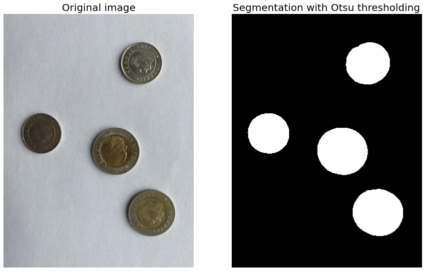

```python
## Segmentation using thresholding
#Segment the coins to obtain a binary image where pixels representing the coins are set to 1.

from skimage import io, color
from skimage.filters import threshold_otsu
import matplotlib.pyplot as plt
from skimage.morphology import disk
from skimage.filters.rank import median
from skimage.transform import rescale

# Load image and convert it to grayscale
!wget -cq https://raw.githubusercontent.com/hazalmogultay/466Images/master/W12/coins.jpeg
im = io.imread('coins.jpeg')
im_g = color.rgb2gray(im)
im_g = rescale(im_g, 0.1, anti_aliasing=False)

# Apply median filter
im_g = median(im_g, disk(3))

# Find the threshold and perform segmentation
thresh = threshold_otsu(im_g)
binary = im_g > thresh

# Swap pixel values
swapped_binary = np.zeros_like(binary)
swapped_binary[binary == False] = 1

plt.figure(figsize=(15,15))
plt.subplot(121)
plt.imshow(im, cmap="gray")
plt.title("Original image", fontsize=20)
plt.axis("off")


plt.subplot(122)
plt.imshow(swapped_binary, cmap="gray")
plt.title("Segmentation with Otsu thresholding", fontsize=20)
plt.axis("off")
```

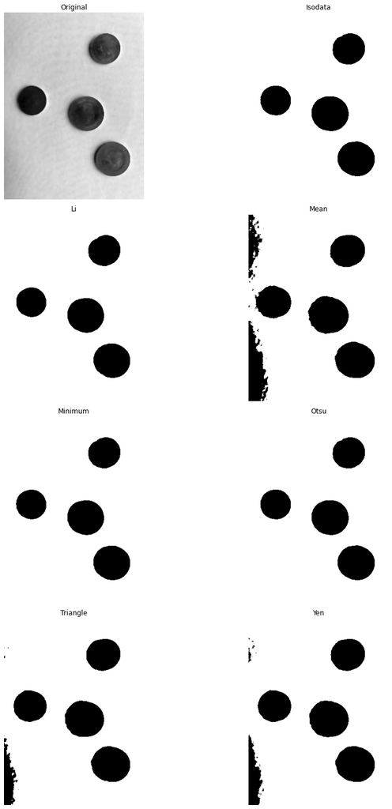

```python
# Try different thresholding approaches on the input

from skimage.filters import try_all_threshold
from skimage import io, color
from skimage.transform import rescale


# Load image and convert it to grayscale
!wget -cq https://raw.githubusercontent.com/hazalmogultay/466Images/master/W12/coins.jpeg
im = io.imread('coins.jpeg')
im_g = color.rgb2gray(im)
im_g = rescale(im_g, 0.1, anti_aliasing=False)

# Apply median filter
im_g = median(im_g, disk(3))

fig, ax = try_all_threshold(im_g, figsize=(15, 20), verbose=False)
plt.show()
```

##### Finding the Valleys of Histogram

The valleys of the histogram between two peaks correspond to the threshold values, when the histogram fits to a Gaussian mixture density function. Then, these threshold values can be directly used for histogram thresholding to generate the segmentation map, without estimating the mean and covariance values of each individual Gaussian components. However, finding the valleys between the peaks of a histogram is not an easy task, because of many reasons:

First of all, in most practical problems the histogram consists of too many supiruous peaks and valleys, other then the modes, due to the textured objects and cluterred background. In order to remove these extra peaks and valleys a simple histogram smoothing method can be employed by averaging several points on a histogram over a sliding window. The selection of the size of the window determines the degree of smoothing and it depends on the application domain.

Secondly, finding the valleys between the modes of a high dimensional histograms in color and multispectral images requires, relatively expensive algorithms, which estimates the minima between the two maxima, in high dimensional spaces.

An effective method to find the valleys of a histogram is to use available high level information about the image content. For example; if we need to segment the letters and background of a document image for an Optical Character Recognition problem, we can use the statistics about the ratio of the object pixels, corresponding to letters and the background pixels, corresponding to white paper and use this ratio to find the threshold value on the histogram.

Also, we can use the available color information about the objects in the image. For example, if we need to segment the sea from the land in a satellite image, we can use the information about the water colors to define a threshold to obtain the segmentation of Figure 24.

[figure not shown]

Figure 23:Segmentation of sea and land using thresholding.

#### Finding Multiresolution Thresholds in Hierarchical Data Structure

Some images consists of a lot of textured objects and cluttered background, which makes the segmentation algorithms inefficient and expensive. In order to reduce the computational complexity and increase the accuracy of the algorithms, first, we find the segmentation map of the downsampled image. Then, the pixels in the boundaries of the segmentation map can be upsampled and resegmented to refine the segmentation map. For this purpose, we can use tree representation of images, where the leaves consists of high resolution image. As we move towards the root, downsampling provides coarser versions of the image. We start from the coarsest level to estimate the thresholds of the color histogram and obtain the segmentation map at the coarse level. At the next level, we upsample only the pixels around the boundaries of the segmentation map and apply histogram thresholding to the upsampled boundary pixels. This coarse to fine segmentation implicitly reduces the noise in the image at the coarser levels and generates a smooth segmentation map, while finetuning it towards the leaves of the tree.

**Algorithm: Multiresolution Thresholding**

**Input:** Tree representation of an image, with $J$ levels.

**Output:** Multilevel segmentation maps.

1. Start from the lowest resolution level,$J-1$ and apply histogram thresholding.
2. Take only boundary pixels of the segmentation map and increase the resolution to the next level.
3. Repeat spets 1 and 2 until reaching the leaves of the tree.

[figure not shown]

Figure 24: Three levels of segmentation map for a satellite image by multiresolution thresholding. b) Low resolution segmentation provides a very coarse boundary. As we increase the resolution around the boundary pixels at each level, we improve the segmentation in c) and d).

#### Consensus Segmentation for Color or Multispectral Images

Most of the segmentation methods mentioned above assume a gray scale image, represented by a one-dimensional histogram. For color images a practical approach is to apply segmentation to only brightness channel of color image represented in the HSI color space.

If the image has multi-spectral vectors for each pixel, we can obtain a bin histogram and apply thresholding to the one-dimensional bin histogram.

Another approach segmenting color or multispectral images is to segment each each color/spectral band independently and develop algorithms to find a consensus segmentation map among the spectral bands.

**Consensus segmentation** is an important field in image processing, which consists of a wide range of algorithms for unifying the outputs of multiple segmentation maps. A simple algorithm can be developed by using logical $AND$ and $OR$ operations applied to the region boundaries of all of the segmentation maps. These logical operations unifies multiple segmentation maps obtained for the same image.

We can fine-tune the unified segmentation map by using a similarity and dissimilarity criterion to split and merge the adjacent segmentation regions until we obtain a unimodal histogram for each region. Formally speaking, suppose that we run several segmentation algorithms on the same image and obtain K segmetation maps, each of which is represented by the region boundaries $B_i$. Then, $OR$ing all the segmentation maps, yield $$B =\bigcup_{i=1}^K B_i.$$

Figure 25 indicates ORing the boundaries of two segmentation maps.This process may result in too many small regions. A final step can merge small regions with respect to a similarity pridicate.

Similarly, $AND$ operations can be applied to the multiple segmentation maps to find the shared boundaries in all the maps.

**Algorithm: Consensus Segmentation by $OR$ Operation**

**Input**: Segmentation maps of the same image, obtained at the output of several segmentation algorithms.

**Output**: A unified consensus segmentation map.

Step 1: Unify all the segmentation maps by ORing all the region boundaries to form a single segmentation map.

Step 2: Finetune the unified segmentation map by merging adjacent regions: For each adjacent pair of regions, compute the multivariate histogram. If the histogram of the merged regions is unimodal, merge them. Else, keep them seperate.

Step 3: Finetune the unified segmentation map by splitting a multimodal histogram: For each region compute the multivariate histogram. If the histogram is multimodal, split the regions by histogram thresholding. Else, keep them the same.

Step 4: Repeat step 3 and 4 until all the regions have unimodal histogrms.

[figure not shown]

Figure 25: ORing the region boundaries of two segmentation maps gives a unified segmentation map.

#### Deterministic Clustering Methods

The statistical clustering methods, given in the previous sections are based on the probability theory. In this set up, we assumed that the color content of an image is represented by two tuples, $(c_k, p(c_k))$, where $c_k$ is a random variable and $p(c_k)$ is the associated probability density function, which can be approximated by the normalized color histogram,

$$p(c_k)\approx\frac{h(c_k)}{NM}.$$

Then, we apply statistical techniques to estimate the modes of the histogram, each of which corresponds to a cluster.

Deterministic clustering methods are based on optimization theory, where we minimize the within cluster similarity and/or maximize between cluster dissimilarity among the samples of the dataset, with respect to a similarity and/or dissimilarity criterion. There are a wide range of methods, which group the "similar" objects using deterministic clustering techniques.

An important class of deterministic clustering techniques use graph theoretical approaches, where the image is represented by a graph or by a hierarchical tree. Then, the tree or graph is partitioned into subtrees or subgraphs with respect to a homogeneity predicate. A popular hierarchical tree segmentation method is already explained in the split and merge algorithm, where we split the image in a quad tree data structure.

An important class of graph based methods is the spectral clustering, which is explained below.

##### Spectral Clustering

Suppose that we represent an image with a graph, $G =(V,W),$ where the set of nodes \ $$v_i \in V,$$

corresponds to each pixel, $p_i$, with a color vector $c_k$ and coordinate $(x_i,y_i)$. The weights of the edges of the graph $$w_{ij} \in W,$$ represents pixel similarity or dissimilarity measure between pixels $p_i$ and $p_j$.

**Motivating Question**: How do we define the edge weights of the graph similarity matrix?

There is a variety of methods for defining the edge weights, which take into account two criteria:

1. Spatial proximity of pixels
2. Color similarity of pixel

An intuitive edge weight is proposed by Shi as follows:

**Definition: Graph similarity matrix, $W =[w_{ij}]$**, is defined as an $(NMxNM)$ dimensional matrix with the entries, $w_{ij}$ given below,

$$w_{ij} = e^{-[\frac{D(c_i,c_j)^2}{\sigma_c^2} + \frac{D(p_i,p_j)^2}{\sigma_s^2}]},$$

where $$D(c_i,c_j) =\sqrt{ (r_i-r_j)^2+(g_i-g_j)^2 +(b_i-b_j)^2},$$

is the Euclidean distance between two color vectors, $\bf{c_i}$ and $\bf{c_j},$ represented in RGB color space and $$D(p_i,p_j) = \sqrt{ (x_i-x_j)^2+(y_i-y_j)^2}$$

is the spatial distance between two pixels, $p_i$ and $p_j$.

The color variance $\sigma_c$ and spatial distance variance $\sigma_s$ are normalization factors for the color and spatial distance measures, respectively.

Considering the very large size of the graph, we can sparcify the graph similarity matrix by setting, $$w_{ij} = 0 \quad \text{for} \quad D(p_i,p_j) \gt T,$$

Note that each row, $i$, of the graph similarity matrix, shows an image generated by finding the similarities of the corresponding pixel, $p_i$ to the rest of the pixels (See; Figure 27).

For an $NxM$ image there are total of $NxM$ nodes of the graph, $G$. Thus, the edge weights form a graph similarity matrix, $$W = [w_{ij}]$$

of dimension $(N\times M)\times(N\times M).$

[figure not shown]

Figure 27: (From Jianbo Shi) The red and blue pixels indicated in the image (upper left) correspond to two nodes, $v_i$ and $v_j$ of the image graph, $G = \{V, W\}$, represented by the graph similarity matrix, $W$. The $i^{th}$ and $j^{th}$ row of the graph similarity matrix show the similarities of these pixels to the rest of the pixels. The upper image in the right corresponds to row $i$, and it is generated by using the edge weights, $w_{ik}$ for all $k=1,....,NM$. The lower image in the right corresponds to the row $j$.

Spectral clustering methods generate a segmentation map by partitioning the image graph, $G$, into a set of subgraphs, $G_i$, by minimizing the similarities among them. Each subgraph corresponds a homogenous image region, corresponding to objects or object parts.

**Motivating Question:** How can we find the "best" partition of a graph, $G$, with respect to a distance measure, defined for each edge weight, so that the subgraphs of the partition provides us the "most" homogenous image regions? Also, this partition should provide us the most dissimilar regions across the subgraphs with respect to a distance measure between the nodes (pixels) of the graph.

[figure not shown]

Figure 28: (From Jianbo Shi) The image in the right can be represented by a graph, $G$, on the left. The nodes of this graph represents the pixels or pixel groups of the same color. If we can partition this graph into two subgraphs with respect to a similarity defined over the edge weights, we can obtain the segmentation map, overlayed on the image.

In order to answer the above question, we need to define basic concepts of spectral graph theory.

**Basic Terminology of Spectral Graph Theory**

Loosely speaking, spectral graph theory is about studying the properties of graphs using the eigenvalues and eigenvectors of the graph similarity matrix, $W$.

**Definition: Eigenvector and Eigenvalue of a Matrix:** Given a matrix $W$, a vector $x\neq 0$ is defined as an eigenvector of $W$, if and only if there is a scalar coefficient, $\lambda$, such that $$Wy = λy,$$

where the scalar, $\lambda$ is called an eigenvalue of $W$.

**Definition: Spectrum of a Graph**: Let $W$ be the similarity matrix of an undirected and weighted graph, $G$, with $(N\times M)$ vertices. Then, $W$ has $(N\times M)$ real eigenvalues. The sorted eigenvalues of this graph,

$$\lambda_1\lt\lambda_2...\lt\lambda_{N\times M},$$

is defined as the spectrum of graph, $G.$ As we shall see in the following subsections, the spectrum of Graph Similarity Matrix, $W$ can be used to partition the associated graph into subgraphs.

**Definition: Node Degree Matrix:** Node degree of a vertex $v_i$ is defined as the total weights of all edges connected to that node;

$$d_i = \sum_{\forall v_j\in V} w_{ij}.$$

As it can be seen from the above definition, node degree is the sum of all the entries in row $i$ of the graph similarity matrix. Node degree, $d_i$, measures how much a node $v_i$ is connected to the graph $G$. Node degree matrix, $D$, is an $(N\times M)\times (N\times M)$ diagonal matrix, where along the main diagonal the node degree of each vertex takes place, as follows;

$$\Delta= \begin{bmatrix}d_i \qquad \quad& ... & 0 \\ && \\ 0 \qquad \quad& ... & d_{MN}\end{bmatrix}.$$

[figure not shown]

Figure 26: (From Jianbo Shi) For an NM-dimensional image, each pixel is represented by a vector in a 2-dimensional color space (left). The distance between pixel $p_i$ and the rest of the pixels are shown by the red arrows. These pixels correspond to the nodes $v_i$ of the image graph $G$ (upper right). Degree of a node is the sum of all the entries at the $i{th}$ row of the graph similarity matrix (lower right). This corresponds to the sum of the edge weights connected to node (pixel),$v_i$ of the image graph (upper right).

**Definition: Association** of a subgraph, $A$, where $A\subset G$ is defined as the total node degrees of the nodes in $A$, as defined below;

$$Asso(A,G) = \sum_{v_i \in A}d_i,\quad A\subseteq G.$$

Association of a subgraph, $A$, measures how much $A$ is connected to the graph $G$ as a whole.

**Definition: Cut in a Graph** is defined as partitioning it into two subgraphs, as follows;

$$cut(A, \bar{A}) = \sum_{v_i\in A, v_j \in \bar{A}}w_{ij},$$

where $\bar{A}$ is the complement of $A$, such that $A\cup\bar{A} =G.$

[figure not shown]

Figure 27: (From Jianbo Shi) Cut in a graph (red edges of the upper left graph) partitions the graph into two subgraphs, $A$ and $\bar{A}$. These subgraphs represents two mutually exclusive and collectively exhaustive image regions. The cut between subgraphs $A$ and $\bar{A}$ corresponds to a submatrix (red submatrix in lower left) in the graph similarity matrix, $W$.

The above definition of $cut(A,\bar{A})$ measures how much the subgraphs, $A$ and $\bar{A}$ are connected to each other. The minimum $cut(A,\bar{A})$ gives us the best partition of the graph $G$ into two subgraphs, which minimizes the sum of the weights between the two subgraphs, as shown in Figure 31.

[figure not shown]

Figure 28: The subgraphs $A$ and $\bar{A}$ are connected to each other by the weights, $w_1$ and $w_2$. if $cut(A, \bar{A})= w_1+w_2$ is minimum, then we obtain the best partition of $G$ .

Recall that our goal was to partition a graph into a set of subgraphs, which generates a segmentation map. Therefore, if we develop an algorithm, which minimize the cut given above, we expect to get the best segmentation map of an image into two regions. Unfortunately, the above definition of cut favors cutting off small node groups. In order to avoid this problem we define normalized cut.

**Definition: Normalized Cut** is defined as

$$Ncut(A,\bar{A}) = \frac{cut(A,\bar{A})}{Asso(A,G)} + \frac{cut(A,\bar{A})}{Asso(\bar{A},G)}$$

In the above definition, dividing the $cut(A,\bar{A})$ by $Asso(\bar{A},G)$ and $Asso(A,G)$ makes the normalized cut independent of the degree of connectivity of the subgraphs $A$ and $\bar{A}$ to the graph $G$. Consequently, Ncut avoids partitioning the image graph into a very small and a very large subgraph. Therefore, if we can develop an algorithm, which iteratively partitions a graph into two subgraphs with minimal normalized cut, we can obtain the best segmentation map for the corresponding image with respect to the similarities defined by $w_{ij}$.

**Example:** Suppose that we partition the graph given in Figure 32 below into two subgraphs $A$ and $B$, where the red edges show the cut. Find the normalized cut.

[figure not shown]

Figure 29: Graph $G$ is partitioned into two subgraphs, $A$ and $B$, where the red edges indicate the cut.

```python
%%HTML

<figure><p align="center"><iframe width="560" height="315" src="https://www.youtube.com/embed/cxTmmasBiC8" frameborder="0" allow="accelerometer; autoplay; encrypted-media; gyroscope; picture-in-picture" allowfullscreen></iframe></p><figcaption>Video 4: </figcaption></figure>
```

[video not shown]

Video 4:

```python
%%HTML
<video width="400" controls>
  <source src="https://raw.githubusercontent.com/hazalmogultay/466Images/master/W12/shi.mp4" type="video/mp4">
</video>
<p>
Video 5:
</p>
```

[video not shown]

Video 5:

#### Jianbo Shi's Graph-Partitioning Algorithm

**Motivating Question:** How can we partition the vertices of a weighted graph into two disjoint subgraphs, so that the normalized cut is minimum?

The answer to the above question requires an exhaustive search for finding the best partition. However, an approximate solution, which gives a high similarity within each set and a low similarity across different sets is possible by using the eigenvalues and eigenvectors of the graph similarity matrix, $W$.

Let us gain some intuition about the relationship between the similarity of vertices (corresponding pixels) of a graph and the eigenvectors of the corresponding graph similarity matrix, $W$. Consider the data set of Figure 33, which consists of three groups of very similar points, indicated by red, blue and gray. These data points can be represented by a graph, where the edge weights indicate a sort of similarity measure between the data points. The corresponding graph similarity matrix, shown in lower right can be rearranged by shuffling the rows and columns to obtain three submatrix, along the main diagonal, each of which represents a subgraph of similar data points im red, blue and gray. This type of matrices are called **block matrices**, which is interpreted as having been broken into submatrices, called blocks.

**Motivating Question:** Can we determine the submatrices of similar entries from the eigenvectors of the graph similarity matrix?

[figure not shown]

Figure 30: Suppose that we a data set with three groups of similar points, indicated by red, blue and gray. These data poins can be represented by a graph, where the edge weights indicate the degree of similarity between the data points. The corresponding graph similarity matrix, shown in lower left can be rearranged to obtain three submatrices, along the main diagonal, each of which represents a subgraph of similar data samples, shown in red, blue and gray.

**Motivating Question:** How do the eigenvectors of block matrices look like?

Let us gain some intuition by considering the simple block matrix of Figure 34 and the eigenvalues and eigenvectors of this matrix. Note that the eigenvectors, corresponding to the nonzero eigenvalues are also block vectors. If we slightly distort the entries of a block matrix, we obtain a near block eigenvectors, as it can be seen from Figure 34.

[figure not shown]

Figure 31: Block matrices have block eigenvectors and near block matrices near block eigenvectors.

Therefore, if we shuffle the rows of the eigenvectors to form near-block vectors, the same shuffling, applied to the corresponding matrix, becomes a near block matrix, where similar data points fall into the same block.

[figure not shown]

Figure 32: The rows of the eigenvectors can be shuffled to obtain near-block eigenvectors.

The above intuitive analysis shows that it is possible to group the similar vertices of a graph by finding the eigenvectors, corresponding to non-zero eigenvalues, of the graph similarity matrix. Then, we can shuffle the rows of the eigenvectos and the graph similarity matrix to form the block matrices, where each block in the matrix shows the vertices, which are similar to each other. The complementing blocks of the graph similarity matrix show the cut of the graph, as shown in Figure 36.

[figure not shown]

Figure 33: Arranging the rows of the eigenvectors generates near block eigenvectors. If we shuffle the rows of the corresponding matrix, we can obtain a near-block matrix. Blocks of the graph similarity matrix, namely, $A$ and $B$ correspond to the subgraphs of the graph $G$. The association of $A$ and the graph $G$ is shown by the green dashed submatrix. The association of $B$ and the graph $G$ is shown by the yellow dashed submatrix. Cut (A,B) is shown by the blue submatrices. Note that the two blue submatrices are the same due to the symmetry property of the graph similarity matrix, $W$.

> **Definition: Characteristic vector:** Suppose that a graph G is partitioned into to subgraphs, $A$ and $\hat{A}$. The characteristic vector, $\bf{x}= [x_i]$ of a the graph $G$, which partitions $A$ and $\hat{A}$, is defined as;

$$x_i = 1 \quad \text{if node} \quad v_i\in A,$$

$$x_i = -1 \quad \text{if node} \quad v_i\in \hat{A}.$$

**Q**: How to find the entries, $x_i$, of the characteristic vector, $\bf{x}$, which minimizes the normalized cut, defined in the previous section.

An approximate solution to the above question can be obtained using the following theorem:

> **Theorem:** Let, $\bf{x}$ be the characteristic vector, which minimizes the normalized cut cost function. Define a vector, $\bf{y}$ as a continuous approximation of $\bf{x}$, as follows; $$\bf{y}=(1+x) - \frac{\sum_{x_i>0}d_i}{\sum_{x_i<0}d_i}(1-x),$$ where $d_i$ is the node degree of vertex, $v_i$.

> Then, $\bf{y} $ is the eigenvector of the smallest eigenvalue, $\lambda\neq 0$ satisfying, $$(\Delta – W) \bf{y} = λ .\Delta \bf{y}.$$

> Since $\bf{y}= [y_1,...., y_{MN}]$ is an approximation of the characteristic vector, $\bf{x}$, the sign of the entries of $\bf{y}$ shows almost optimum partition of the graph, $G$, to two subgraphs, as follows: $$y_i \gt 0 \quad \text{if node} \quad v_i\in A,$$ $$y_i \le 0 \quad \text{if node} \quad v_i\in \hat{A}.$$

The proof of the above theorem is beyond the scope of this book. The interested reader can study the paper by Shi et. al. (https://ieeexplore.ieee.org/document/868688). > The above theorem enables us to split a graph into two subgraphs with "approximately minimum" normalized cut. If further subdivision is merited, we can repeat dividing each subgraph, recursively.

> **Algorithm: N-Cut Segmentation**
> 1. Compute the entries of the graph similarity matrix, $W =[w_{ij}]$, from the following equation: : $$w_{ij} = e^{-[\frac{D(c_i,c_j)^2}{\sigma_l^2} + \frac{D(p_i,p_j)^2}{\sigma_s^2}]},$$ where $$D(c_i,c_j) =\sqrt{ (r_i-r_j)^2+(g_i-g_j)^2 +(b_i-b_j)^2}$$ is the Euclidean distance between two color vectors, $\bf{c_i}$ and $\bf{c_j},$ represented in RGB color space and $$D(p_i,p_j) = \sqrt{ (x_i-x_j)^2+(y_i-y_j)^2}$$

is the spatial distance between two pixel, $p_i$ and $p_j$. >

> 1. Compute the entries of node degree matrix, $D$, as follows; $$d_i = \sum_{\forall v_j\in V} w_{ij}.$$
> 2. Compute the eigenvectors $\bf{y}$ of the following equation $$(\Delta-W)\bf{y} = \lambda. \Delta .y$$
> 3. Use eigenvector with the smallest eigenvalue, $\lambda\neq 0$, to bipartition the graph as follows; $$y_i \gt 0 \quad \text{if node} \quad v_i\in A,$$ $$y_i \le 0 \quad \text{if node} \quad v_i\in \bar{A}.$$
> 4. Decide if re-partition current partitions.

N-cut segmentation algorithm is a generic bipartite graph partitioning algorithms, which approximately minimizes the **normalized cut** cost function. The choice of the entries of graph similarity matrix, $W$ is flexible. The algorithm does not require any model for data distribution. However, computation of the $NxM$ eigenvectors is quite expensive, specially when the size of the image is big.

[figure not shown]

Figure 34: Segmentation maps for blobworld images,v obtained at the output of n-cur segmentation method.

### Superpixels

In order to reduce the computational complexity of n-cut segmentation method, we can apply a fast segmentation algorithm, which oversegments the image, prior to the n-cut segmentation method. The homogeneous regions obtained in the oversegmented image are called **superpixels**. Then, instead of defining image as a graph of pixels, we can set each node of the image graph as a superpixel.

As an example, we may employ K-means segmentation algorithm with very high number of K-value prior to the n-cut segmentation algorithm. The segmentation map obtained at the output of this algorithm partitions the image into small convex regions, such that each region lies within object boundaries. Then, we generate a graph of superpixels,

$$G_{sp} =\{r_i\in V, w_{ij}'\in W'\},$$

where the nodes $r_i$ correspond to superpixels and the edges $w_{ij}'$, correspond to similarity measure between the regions, $r_i$ and $r_j.$ Then, n-cut segmentation can be applied to this relatively small graph.

[figure not shown]

Figure 35: Superpixels, adapted from @2017 Selim Aksoy (http://ivrl.epfl.ch/research/superpixels )

```python
%%HTML
<video width="400" controls>
  <source src="https://raw.githubusercontent.com/hazalmogultay/466Images/master/W12/GraphSegmentation.mp4" type="video/mp4">
</video>
<p>
Video 6:
</p>
```

[video not shown]

Video 6:

#### Application of N-Cut Segmentation

N-Cut segmentation algorithm is widely used in many application areas. One important field is neuroscience, where the researchers investigate the regions of brain responsible of performing a specific cognitive task, such as problem solving. BrainParcel is a brain parcellation algorithm which utilizes N-Cut segmentation method, for understanding and classifying cognitive states [H. Mogultay and F.T. Yarman Vural, 2018/9/20 Graphs in Biomedical Image Analysis and Integrating Medical Imaging and Non-Imaging Modalities32-42, Springer, Cham]

Functionality of human brain is extensively researched. One of the questions, that highly attracts attention of the Neuroscientists, is on understanding **how the human brain learns**. In order to answer this question, functional magnetic resonance imaging (fMRI) signals are recorded while a subject performs a cognitive task. fMRI technique generates a discrete time signal at each voxel (an almost $1\ mm^3$ volume element), as shown in Figure 38. These time series recorded at each voxel, form a brain volume at each time instant.

Previous research revealed that neurons act in accordance with each other to perform a task. Therefore, brain regions performing a cognitive task have similar voxel time series. Extracting the **homogeneous segments** of human brain that is specialized for a specific task is an important question in neuroscience community.

Human brain is biologically segmented into regions, which are called **anatomical regions**. However, these anatomical regions are flexible and can change depending on many factors, such as the type of the task, age, sex, genetic properties etc. Thus, segmentation of brain into a set of homogeneous regions, under a specific cognitive task reveals important information about the activities in these regions, responsible on this task.

The first step for brain segmentation is to find a graph representation, $$G= \{v_i\in V, w_{ij}\in W\}$$

of fMRI time series, recorded under a cognitive stimulus. The nodes correspond to voxles, with (x,y,z) coordinates. The arc weights, $w_{ij}$, are a measure of similarity between the time series of voxels $v_i$ and $v_j.$

Suppose that the time series recorded in voxels $v_i$ and $v_j$ can be represented by a d-dimensional vector, $$v_i =[v_i(1),....v_i(d)]$$ and

$$v_j =[v_j(1),....v_j(d)],$$

where the dimension, $d$ indicates the total number of time samples, recorded during a cognitive stimulus. A simple similarity measure between two discrete time signals can be measured by Pearson correlation coefficient, defined below;

$$w_{ij} = \rho (v_i,v_j) = \frac{[v_i-\mu_{v_i}]^T[v_j-\mu_{v_j}]}{\sqrt{[v_i-\mu_{v_i}]^T[v_i-\mu_{v_i}].[v_j-\mu_{v_j}]^T[v_j-\mu_{v_j}]}},$$

where

$$\mu_{v_i}= \frac{1}{d}\sum_{k=1}^d v_i(k).$$

[figure not shown]

Figure 36: fMRI Signals generate a discrete time signal (right) at each coordinate, called voxel. High intensity signals in the left image are shown with hot colors. As the intensity gets lower, we use colder colors.

Therefore, a brain graph, $G=\{V, W\}$, can be generated by assigning each voxel a node $v_i\in V$ and defining a similarity matrix $W=[w_{ij}]$, as shown in figure 39.

[figure not shown]

Figure 37: Representing brain signals as a graph G=(V,W)

[figure not shown]

Figure 38: Schematic representation of a brain graph, defined across the voxels.

At this point, we can apply, n-cut segmentation method to partition the brain graph into homogeneous regions, as shown in Figure 41. This partitions can, then, be used to analyse the contribution of each region to process aa cognitive stimulus.

[figure not shown]

Figure 39: N-cut segmentation output: 3-Dimensional homogeneous brain regions

**Programming exercises:**

1. Run the following code to obtain superpixels using SLIC algorithm and normalize cut to merge superpixels.
2. Change compactness and number of segments parameters of SLIC and observe how the superpixels change.

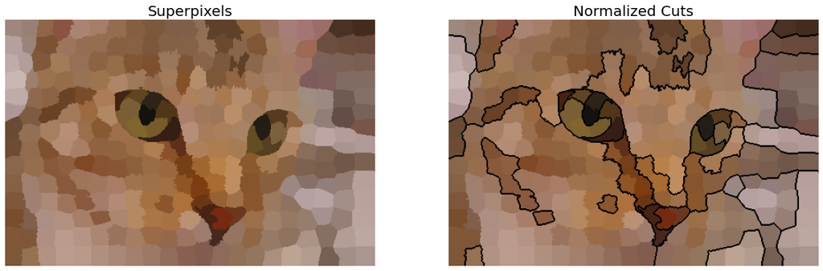

```python
from skimage import data, segmentation, color
from skimage.future import graph
from matplotlib import pyplot as plt
import numpy as np
from skimage import io, feature, color
from skimage.transform import rescale

img = data.chelsea()

# Generate superpixels using SLIC algorithm that segments image using k-means clustering in Color-(x,y,z) space
segments = segmentation.slic(img, compactness=30, n_segments=300)
superpixels = color.label2rgb(segments, img, kind='avg')

# Create a Region Adjancy Graph. Each node is a superpixel and the weight between adjacent superpixels represents how similar two regions are.
g = graph.rag_mean_color(img, segments, mode='similarity')

# Perform a normalized cut
graph_cut_segments = graph.cut_normalized(segments, g, thresh=0.01)
graph_cut_output = segmentation.mark_boundaries(superpixels, graph_cut_segments, (0, 0, 0),mode='thick')


plt.figure(figsize=(20,20))
plt.subplot(121)
plt.imshow(superpixels.astype('int'))
plt.axis('off')
plt.title('Superpixels', fontsize=20)

plt.subplot(122)
plt.imshow(graph_cut_output.astype('int'))
plt.axis('off')
plt.axis('off')
plt.title('Normalized Cuts', fontsize=20)
```

# Chapter Summary

How can we partition an image into "homogeneous" regions, which may correspond to objects or object parts? How can we define homogeneity of a region? What are the available mathematical tool to partition an image into meaningful regions?

Segmentation algorithms receive an input image, which consist of a bunch of pixels and outputs an indexed set of pixels, which may correspond to objects or object parts. It may also extract geometrical structures, such as, line segments, circles, ellipses, polygons and convex curve segments.

There are two major categories of segmentation methods, namely, region based and edge based methods. In this chapter, we studied the region based methods, based on deterministic and statistical techniques. The most popular statistical image segmentation methods are K-means and mean shift algorithms. These methods assume that the normalized color histogram approximates a mixture of Gaussian probability density function. Then, it estimates the mean and variance of each component in the mixture. The deterministic image segmentation methods, define a similarity or dissimilarity predicate to merge or split image regions. The most popular deterministic image segmentation technique is n-cut clustering, which assumes that an image is represented by a graph. Then, it partitions the graph into subgraphs, where each subgraph consists of collection of similar pixels. N-cut segmentation algorithm uses spectral graph theory to efficiently partition image graph, where the nodes correspond to the pixels and edge weights correspond to the pixel similarity with respect to a predefined predicate.